# Potential Outcomes, Random Assignment

Shikhar Singh

August 26, 2026

# Agenda

### 1. Potential Outcomes

- Causal Estimand #1: Individual-level Causal Effect
- Causal Estimand #2: Average Treatment Effect

### 2. Fundamental Problem of Causal Inference (FPCI)

- Switching Equation

### 3. Random Assignment

- What is it? Simple v. Complete Random Assignment
- Random Assignment and FPCI
- Estimand, Estimator, Estimate ($d_i$ v. $D_i$)

# Potential Outcomes

Every subject $i$ has two *potential* outcomes, $Y_i(1)$ (the outcome when subject $i$ is treated), and $Y_i(0)$ (the outcome when subject $i$ is untreated).

The causal effect of treatment ($\tau_i$) is defined as

> $$\begin{equation} \tau_i \equiv Y_i(1) -
> Y_i(0) \end{equation}$$

Schedule of Potential Outcomes and Individual Level Treatment Effects

| Unit | Y1 | Y0 | tau |
| --- | --- | --- | --- |
| 1 | 10 | 15 | -5 |
| 2 | 10 | 13 | -3 |
| 3 | 16 | 11 | 5 |
| 4 | 8 | 9 | -1 |

The average treatment effect ($\mathbb{E}[\tau_i]$) is defined as

> $$\begin{equation}\text{ATE} = E[\tau_i] =
> E[Y_i(1) - Y_i(0)] = \frac{1}{N} \sum_{i=1}^N \tau_i = \frac{1}{N}
> \sum_{i=1}^N Y_i(1) - Y_i(0)\end{equation}$$

**Exercise:**Calculate the ATE by taking the average of the third column, $\mathbb{E}[\tau_i]$, or the difference between the average of the first column, $\mathbb{E}[Y_i(1)]$, and the second column, $\mathbb{E}[Y_i(0)]$.

# Fundamental Problem of Causal Inference

> The **fundamental problem of causal inference** is that we never observe both potential outcomes for any subject $i$. In the real world, when subjects are randomly assigned to treatment conditions, they reveal one of their potential outcomes. Call this $Y_i$ or the observed outcome.

According to the **switching equation**, the revealed or observed outcome is:

> $$\begin{equation} Y_i = \underbrace{d_i
> \cdot Y_i(1)}_{\text{When i is in control, this equals 0 and}
> Y_i=Y_i(0)} + \underbrace{(1 - d_i) \cdot Y_i(0)}_{\text{When i is in
> treatment, this equals 0 and} Y_i=Y_i(1)} \end{equation}$$

Observed V. Full Data

| Unit | Y1 | Y0 | tau | D_i | Obs Y1 | Obs Y0 | Y |
| --- | --- | --- | --- | --- | --- | --- | --- |
| 1 | 10 | 15 | -5 | 1 | 10 | ? | 10 |
| 2 | 10 | 13 | -3 | 1 | 10 | ? | 10 |
| 3 | 16 | 11 | 5 | 0 | ? | 11 | 11 |
| 4 | 8 | 9 | -1 | 0 | ? | 9 | 9 |

# Random Assignment

> Random assignment refers to the procedure that allocates treatments with known probabilities that are greater than zero and less than one. (FEDAI:32)

There are two types of random assignment:

**Simple random assignment** refers to a procedure in which every subject is assigned to the treatment group with probability $\frac{m}{N}$.

Say there are 10 subjects and the probability of being assigned to the treatment group is $p_i=\frac{4}{10}=0.4$. That is, every subject has a 40% chance of being in the treatment group. For every subject $i$, we “flip a coin” with a success probability of 40%. Note that such a procedure will not yield exactly $m$ subjects in the treatment group.

**Complete random assignment** refers to a procedure in which *exactly* $m$ of $N$ subjects are assigned to treatment.

Say we want to assign exactly $m=4$ out of $N=10$ to treatment group, we can do one of two things:

- “Enumerate all the possible ways that $m$ subjects may be selected from a list of $N$ subjects, and randomly select one of the possible allocation schemes.” (FEDAI:36)
- “Randomly permute the order of all $N$ subjects and label the first $m$ subjects as the treatment group” (FEDAI:36)

## Properties

Random assignment ensures that treatment assignment is independent of potential outcomes:

$$\begin{equation}
Y_i(0), Y_i(1), X \perp\!\!\!\perp D_i
\end{equation}$$

That is to say, subjects with a certain type of potential outcome (“high” or “low”) are not systematically selected into treatment or control. Every subject has a known, non-zero probability of being in treatment or control.

By implication, the subjects in the treatment group are a *random subset* of all subjects:

$\underbrace{\mathbb{E}[Y_i(1) | D_i = 1]}_{\text{expected value of Y1 in the treatment group}} = \underbrace{\mathbb{E}[Y_i(1)]}_{\text{expected value of Y1 in the population}}$

Since the remaining subjects in the control group are also a *random subset* of the population:

$\underbrace{\mathbb{E}[Y_i(1) | D_i = 0]}_{\text{expected value of Y1 in the control group}} = \mathbb{E}[Y_i(1)]$

Put together:

$\mathbb{E}[Y_i(1)] = \mathbb{E}[Y_i(1) | D_i = 1] = \mathbb{E}[Y_i(1) | D_i = 0]$

Similarly, for the untreated potential outcome:

$\mathbb{E}[Y_i(0)] = \underbrace{\mathbb{E}[Y_i(0) | D_i = 1]}_{\text{expected Y0 in the treatment group}} = \underbrace{\mathbb{E}[Y_i(0) | D_i = 0]}_{\text{expected Y0 in the control group}}$

### Random Assignment and FPCI

We start with the fundamental problem of causal inference, which is a **missing data problem**.

The average treatment effect (ATE) cannot be estimated because we don’t have the treated potential outcome $Y_i(1)$, for subjects in the control group and the untreated potential outcome $Y_i(0)$ for subjects in the treatment group.

However, random assignment allows us to say:

$\mathbb{E}[Y_i(1)] = \mathbb{E}[Y_i(1) | D_i = 1]$

and

$\mathbb{E}[Y_i(0)] = \mathbb{E}[Y_i(0) | D_i = 0]$

Which means, we can re-write the ATE as:

$\mathbb{E}[Y_i(1)] - \mathbb{E}[Y_i(0)] = \mathbb{E}[Y_i(1) | D_i = 1] - \mathbb{E}[Y_i(0) | D_i = 0]$

The latter quantity is estimable: we can calculate the expected value of $Y_i(1)$ in the treatment group, and the expected value of $Y_i(0)$ in the control group.

## Estimand, Estimator, Estimate

An **estimand** is a population-level quantity of interest. The average treatment effect (or ATE) is one such estimand.

In a population of $N$ people,

> $$\begin{equation}\text{ATE} = E[\tau_i] =
> E[Y_i(1) - Y_i(0)] = \frac{1}{N} \sum_{i=1}^N \tau_i = \frac{1}{N}
> \sum_{i=1}^N Y_i(1) - Y_i(0)\end{equation}$$

An **estimator** is a procedure or rule for estimating the given quantity based on some observed data. The **difference-in-means** is an estimator that uses observed data or $Y_i$ to estimate the average treatment effect.

> $$\begin{equation}\text{DIM} =
> \frac{\sum_{1}^m Y_i}{m} - \frac{\sum_{m+1}^N Y_i}{N - m}
> \end{equation}$$

where $m$ of $N$ subjects are assigned to the treatment condition.

An **estimate** is one particular result or guess of the quantity of interest, given some data.

**Exercise:** Calculate the true ATE and ATE estimate.

Observed V. Full Data

| Unit | Y1 | Y0 | tau | D_i | Obs Y1 | Obs Y0 | Y |
| --- | --- | --- | --- | --- | --- | --- | --- |
| 1 | 10 | 15 | -5 | 1 | 10 | ? | 10 |
| 2 | 10 | 13 | -3 | 1 | 10 | ? | 10 |
| 3 | 16 | 11 | 5 | 0 | ? | 11 | 11 |
| 4 | 8 | 9 | -1 | 0 | ? | 9 | 9 |

## $d_i$ v. $D_i$

To understand why the true ATE is conceptually and empirically different from an *estimate* of the ATE, lets focus on the difference between $d_i$ and $D_i$.

You’ll note that in the preceding section we used $D_i$ for most of our notation, not $d_i$.

### Difference between $d_i$ and $D_i$

- $d_i$ is the observed treatment assignment of unit $i$
- $D_i$ is a random variable that indicates whether unit $i$ would be treated in a hypothetical experiment.

In words: $d_i$ is a particular realization of $D_i$.

#### An example with $n$=4, $m$=2

Schedule of Potential Outcomes and Treatment Assignment

| Unit | Y1 | Y0 | d_i |
| --- | --- | --- | --- |
| 1 | 10 | 15 | 1 |
| 2 | 10 | 13 | 1 |
| 3 | 16 | 11 | 0 |
| 4 | 8 | 9 | 0 |

In this study, we randomly assigned 2 of 4 subjects to treatment. It so happens that in this iteration of that random assignment procedure, units 1 and 2 get assigned to the treatment condition ($d_i =1$).

However there are many ways in which two of four units can be assigned to a treatment:

${4 \choose 2} = \frac{4!}{2!\times 2!} = 6$ ways

Lets use `randomizr` to get the six different assignment vectors. The R package manual is available [here](https://cran.r-project.org/web/packages/randomizr/randomizr.pdf).

**Step 1**: Installing the package, and librarying it

```r
# If you do not have this package:

# install.packages("randomizr")

library(randomizr)
```

**Step 2:** Declaring the design or randomization procedure

```r
declaration <- declare_ra(N = 4, m = 2) #this gives randomizr the necessary design information

declaration
```

```
## Random assignment procedure: Complete random assignment
## Number of units: 4
## Number of treatment arms: 2
## The possible treatment categories are 0 and 1.
## The number of possible random assignments is 6.
## The probabilities of assignment are constant across units:
## prob_0 prob_1
##    0.5    0.5
```

**Step 3:** Conduct a random assignment, or obtain $d_i$. You will notice that $d_i$ is typically different every time we conduct this assignment procedure.

```r
conduct_ra(declaration) # This uses that information to generate an assignment vector. This vector will be different every time we run the command. See below
```

```
## [1] 0 1 1 0
```

```r
D <- conduct_ra(declaration)
D # Different from the first assignment vector
```

```
## [1] 1 0 1 0
```

**Step 4:** Getting the six possible assignment vectors.

```r
D <- obtain_permutation_matrix(declaration)
# Generates all possible assignment vectors for N=4, m=2

kable(D, caption = "Assignment Vectors")
```

Assignment Vectors

| 0 | 0 | 0 | 1 | 1 | 1 |
| --- | --- | --- | --- | --- | --- |
| 0 | 1 | 1 | 0 | 0 | 1 |
| 1 | 0 | 1 | 0 | 1 | 0 |
| 1 | 1 | 0 | 1 | 0 | 0 |

For any unit $i \in \{1,2,3,4\}$, $d_i = 1$ with probability $\frac{1}{2}$ and 0 with probability $\frac{1}{2}$.

We can manually check this in the table. Unit 1 is assigned to treatment in three of six assignment vectors ($d_i$, $d_4$, and $d_5$ in the table below). Unit 4 is assigned three of six times to treatment as well ($d_1$,$d_2$ and $d_4$).

Now lets see the full science table:

Full Schedule of Potential Outcomes and Treatment Assignments

| Unit | Y1 | Y0 | d_i | d1 | d2 | d3 | d4 | d5 |
| --- | --- | --- | --- | --- | --- | --- | --- | --- |
| 1 | 10 | 15 | 1 | 0 | 0 | 0 | 1 | 1 |
| 2 | 10 | 13 | 1 | 0 | 1 | 1 | 0 | 0 |
| 3 | 16 | 11 | 0 | 1 | 0 | 1 | 0 | 1 |
| 4 | 8 | 9 | 0 | 1 | 1 | 0 | 1 | 0 |

What is $E[Y_i(0)]$?

It is $\frac{15+13+11+9}{4} = \frac{48}{4} = 12$

What is $E[Y_i(0) | d_i = 0]$?

$\frac{Y_3(0) + Y_4(0)}{2} = \frac{11+9}{2} = 10$

What is $E[Y_i(0) | D_i = 0]$?

It is $E_d[E(Y_i(0) | d_i=0)] = \sum_d E(Y_i(0) | d_i=0) \cdot p(d)$

where $p(d)$ is the probability of obtaining that assignment vector.

In our case, there are 6 possible assignment vectors, so $p(d)=\frac{1}{6}$, and the overall quantity is:

$\frac{1}{6}(\frac{Y_3(0) + Y_4(0)}{2}) + \frac{1}{6}(\frac{Y_1(0) + Y_2(0)}{2}) + \frac{1}{6}(\frac{Y_1(0) + Y_3(0)}{2}) + \frac{1}{6}(\frac{Y_1(0) + Y_4(0)}{2}) + \frac{1}{6}(\frac{Y_2(0) + Y_3(0)}{2}) + \frac{1}{6}(\frac{Y_2(0) + Y_4(0)}{2})$

Which equals:

$\frac{1}{6}[\frac{11+9}{2} + \frac{15+13}{2} + \frac{15+11}{2} + \frac{15+9}{2} + \frac{13+11}{2} + \frac{13+9}{2}]$

$\frac{1}{6}[\frac{144}{2}] = 12$

Note that $E[Y_i(0) | D_i = 0] \neq E[Y_i(0) | d_i = 0]$, and that $E[Y_i(0) | D_i = 0] = E[Y_i(0)]$

# Coding Introduction

We will use the `tidyverse` suite of packages in `R` to analyze data from experiments.

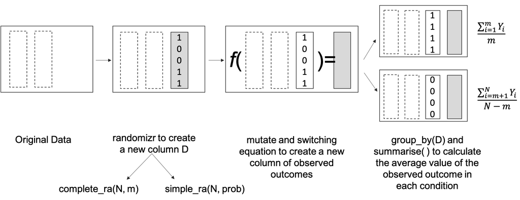

Figure 1: Steps in Tidyverse

**Step 1**: Installing tidyverse packages, and librarying it

```r
# If you do not have this package:

# install.packages("tidyverse")

library(tidyverse)
```

**Step 2:** Lets use data from the above example to estimate the true ATE.

```r
results_estimand <- data1 %>%
  summarise(
    averageY1 = mean(Y1),
    averageY0 = mean(Y0),
    estimand = averageY1 - averageY0
  )

kable(results_estimand,
      caption = "Calculating the true ATE")
```

Calculating the true ATE

| averageY1 | averageY0 | estimand |
| --- | --- | --- |
| 11 | 12 | -1 |

**Step 3:** In the real world, we do not observe people’s potential outcomes. We conduct a study in which people are randomly assigned to conditions and we observe either their treated or untreated potential outcome. We use the difference-in-means estimator to estimate the ATE.

```r
group_means <- data1 %>%
  mutate(
    Y = Y1*d_i + Y0*(1-d_i)
  ) %>%
  group_by(d_i) %>%
  summarise(Average = mean(Y))

kable(group_means,
      caption = "Estimating Group Means")
```

Estimating Group Means

| d_i | Average |
| --- | --- |
| 0 | 10 |
| 1 | 10 |

We can also estimate the difference in means:

```r
estimate <- group_means %>%
  summarise(DIM = Average[d_i==1] - Average[d_i==0])

kable(estimate,
      caption = "Difference in Means")
```

Difference in Means

| DIM |
| --- |
| 0 |

# Practice

Download the dataset uploaded along with this script. Conduct complete random assignment using the `complete_ra` command in `randomizr`, assigning exactly 350 subjects to the treatment condition and the remaining to the control condition. Use the switching equation to create a new column of observed outcoemes, $Y_i$. Estimate the true ATE ($E[Y_i(1) - Y_i(0)])$, and the difference in means estimate ($\frac{\sum_{1}^m Y_i}{m} - \frac{\sum_{m+1}^N Y_i}{N - m}$). Do you get the same answer?

**Note:** I am including the solution code but please attempt doing this without looking at that code in the first instance.

```r
dat <- read_csv("w1_practice_data.csv")

# Conduct complete random assignment

dat <- dat %>%
  mutate(
    d = complete_ra(N = nrow(dat), m = 350),
    Y = Y1*d + (1-d)*Y0
  )

# True ATE

dat %>% summarise(ATE = mean(Y1-Y0))

# DIM estimate in this iteration of the experiment

dat %>% summarise(DIM = mean(Y[d==1]) - mean(Y[d==0]))
```